# Session 10: Data Science Capstone Project

Dr Kanishka Bhattacharya

2024-12-23

# 1 Introduction and learning objectives

The purpose of this exercise is to build an estimation engine to guide investment decisions in London house market. You will first build machine learning algorithms (and tune them) to estimate the house prices given variety of information about each property. Then, using your algorithm, you will choose 200 houses to invest in out of about 2000 houses on the market at the moment.

**Learning objectives**

1. Using different data mining algorithms for prediction.
2. Dealing with large data sets
3. Tuning data mining algorithms
4. Interpreting data mining algorithms and deducing importance of variables
5. Using results of data mining algorithms to make business decisions

# 2 Load data

There are two sets of data, i) training data that has the actual prices ii) out of sample data that has the asking prices. Load both data sets.

Make sure you understand what information each column contains. Note that not all information provided might be useful in predicting house prices, but do not make any assumptions before you decide what information you use in your prediction algorithms.

```r
# Load training and test datasets
london_house_prices_2019_training<-read.csv("training_data_assignment_with_prices.csv")
london_house_prices_2019_out_of_sample<-read.csv("test_data_assignment.csv")

# Fix data types for both datasets
# Convert 'date' columns to Date format
london_house_prices_2019_training <- london_house_prices_2019_training %>% mutate(date=as.Date(date))
london_house_prices_2019_out_of_sample<-london_house_prices_2019_out_of_sample %>% mutate(date=as.Date(date))
# Convert character columns to factors for compatibility with ML algorithms
london_house_prices_2019_training <- london_house_prices_2019_training %>% mutate_if(is.character,as.factor)
london_house_prices_2019_out_of_sample<-london_house_prices_2019_out_of_sample %>% mutate_if(is.character,as.factor)

# Examine structure of the datasets
str(london_house_prices_2019_training)
```

```
## 'data.frame':    13998 obs. of  37 variables:
##  $ ID                          : int  2 3 4 5 7 8 9 10 11 12 ...
##  $ date                        : Date, format: "2019-11-01" "2019-08-08" ...
##  $ postcode                    : Factor w/ 12635 levels "BR1 1AB","BR1 1LR",..: 10897 11027 11264 2031 11241 11066 421 9594 9444 873 ...
##  $ property_type               : Factor w/ 4 levels "D","F","S","T": 2 2 3 2 3 2 1 4 4 2 ...
##  $ whether_old_or_new          : Factor w/ 2 levels "N","Y": 1 1 1 1 1 1 1 1 1 1 ...
##  $ freehold_or_leasehold       : Factor w/ 2 levels "F","L": 2 2 1 2 1 2 1 1 1 2 ...
##  $ address1                    : Factor w/ 2825 levels "1","1 - 2","1 - 3",..: 2503 792 253 789 569 234 264 418 5 274 ...
##  $ address2                    : Factor w/ 434 levels "1","10","101",..: 372 NA NA NA NA NA NA NA NA NA ...
##  $ address3                    : Factor w/ 8543 levels "ABBERTON WALK",..: 6990 6821 3715 2492 4168 2879 3620 5251 6045 6892 ...
##  $ town                        : Factor w/ 133 levels "ABBEY WOOD","ACTON",..: NA NA NA 78 NA NA NA NA NA NA ...
##  $ local_aut                   : Factor w/ 69 levels "ASHFORD","BARKING",..: 36 46 24 36 24 46 65 36 36 17 ...
##  $ county                      : Factor w/ 33 levels "BARKING AND DAGENHAM",..: 22 27 18 25 18 27 5 27 32 8 ...
##  $ postcode_short              : Factor w/ 247 levels "BR1","BR2","BR3",..: 190 194 198 28 198 194 4 169 167 8 ...
##  $ current_energy_rating       : Factor w/ 6 levels "B","C","D","E",..: 4 3 3 4 3 2 4 3 4 2 ...
```

[output cut: 23 more lines]

```r
str(london_house_prices_2019_out_of_sample)
```

```
## 'data.frame':    1999 obs. of  37 variables:
##  $ ID                          : int  14434 12562 8866 10721 1057 1527 13961 12108 9363 1155 ...
##  $ date                        : Date, format: NA NA ...
##  $ postcode                    : logi  NA NA NA NA NA NA ...
##  $ property_type               : Factor w/ 4 levels "D","F","S","T": 1 2 2 3 4 3 2 3 2 4 ...
##  $ whether_old_or_new          : Factor w/ 2 levels "N","Y": 1 1 1 1 1 1 1 1 1 1 ...
##  $ freehold_or_leasehold       : Factor w/ 2 levels "F","L": 1 2 2 1 1 1 2 1 2 1 ...
##  $ address1                    : logi  NA NA NA NA NA NA ...
##  $ address2                    : logi  NA NA NA NA NA NA ...
##  $ address3                    : logi  NA NA NA NA NA NA ...
##  $ town                        : Factor w/ 54 levels "ACTON","ADDISCOMBE",..: NA NA NA NA NA NA NA NA NA NA ...
##  $ local_aut                   : logi  NA NA NA NA NA NA ...
##  $ county                      : logi  NA NA NA NA NA NA ...
##  $ postcode_short              : Factor w/ 221 levels "BR1","BR2","BR3",..: 82 50 37 52 214 150 159 115 175 126 ...
##  $ current_energy_rating       : Factor w/ 6 levels "B","C","D","E",..: 3 2 3 3 4 4 4 3 4 3 ...
```

[output cut: 23 more lines]

```r
# Splitting data into training and testing subsets (75% train, 25% test)
library(rsample)
set.seed(123) # Set seed for reproducibility of data splitting
train_test_split <- initial_split(london_house_prices_2019_training, prop = 0.75)
# Creating training and testing datasets
train_data <- training(train_test_split)
test_data <- testing(train_test_split)
```

# 3 Visualize data

Visualize and examine the data. What plots could be useful here? What do you learn from these visualizations?

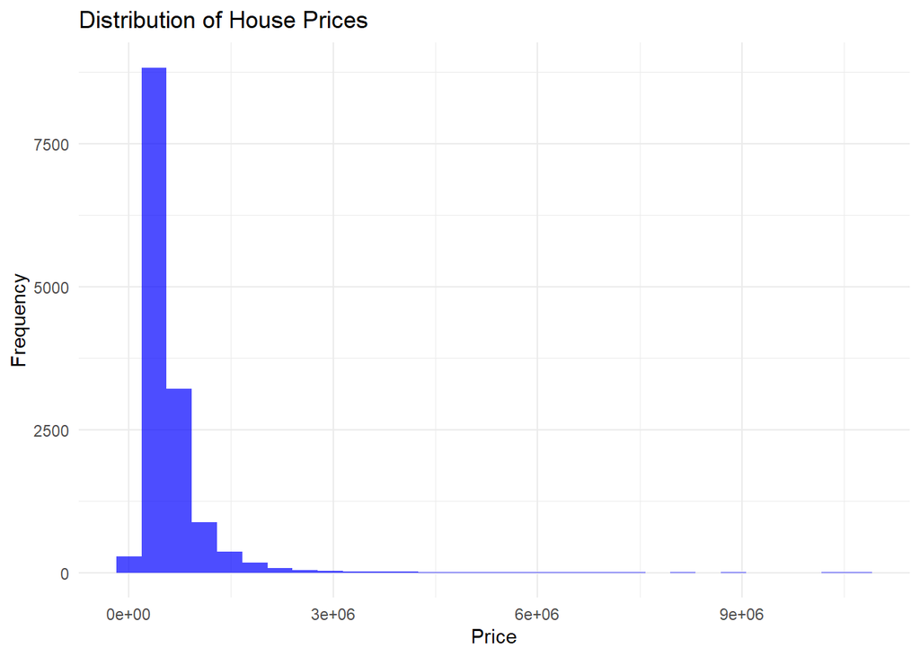

```r
# Visualizing the distribution of house prices
library(ggplot2)
ggplot(london_house_prices_2019_training, aes(x = price)) +
  geom_histogram(bins = 30, fill = "blue", alpha = 0.7) +
  theme_minimal() +
  labs(title = "Distribution of House Prices", x = "Price", y = "Frequency")
```

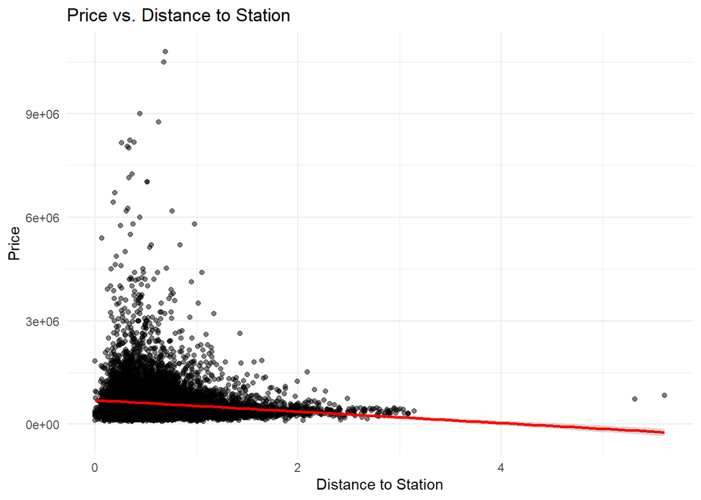

```r
# Scatter plot of house prices vs. distance to nearest station
ggplot(london_house_prices_2019_training, aes(x = distance_to_station, y = price)) +
  geom_point(alpha = 0.5) +
  geom_smooth(method = "lm", col = "red") +
  theme_minimal() +
  labs(title = "Price vs. Distance to Station", x = "Distance to Station", y = "Price")
```

Estimate a correlation table between prices and other continuous variables. What do you glean from the correlation table?

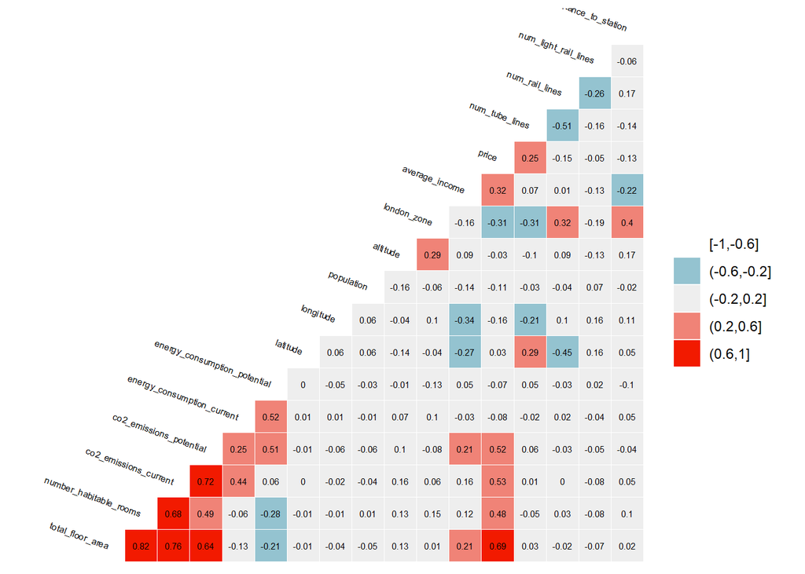

```r
# Estimate a correlation table between prices and other continuous variables
# This helps identify relationships between price and other numerical features
# The GGally::ggcorr function generates a heatmap to visualize these correlations
library("GGally")
london_house_prices_2019_training %>%
  select(-ID) %>% #keep Y variable last
  ggcorr(method = c("pairwise", "pearson"), layout.exp = 2,label_round=2, label = TRUE,label_size = 2,hjust = 1,nbreaks = 5,size = 2,angle = -20)
```

# 4 Fit a linear regression model

To help you get started I build a linear regression model below. I chose a subset of the features with no particular goal. You can (and should) add more variables and/or choose variable selection methods if you want.

```r
#Define control variables
control <- trainControl (
    method="cv",
    number=5,
    verboseIter=TRUE) #by setting this to true the model will report its progress after each estimation

# Define control settings for cross-validation during training
control <- trainControl(
  method = "cv",
  number = 5,
  verboseIter = TRUE,
  savePredictions = "all" # Required for stacking
)

# Train a linear regression model using selected features
set.seed(123) # Set seed for reproducibility of linear regression training
model1_lm <- train(
  price ~ distance_to_station + water_company + property_type + whether_old_or_new + freehold_or_leasehold + latitude + longitude,
  data = train_data,
  method = "lm",
  trControl = control
)
# Summarize the linear regression results to examine coefficients and fit
summary(model1_lm)
```

```
##
## Call:
## lm(formula = .outcome ~ ., data = dat)
##
## Residuals:
##     Min      1Q  Median      3Q     Max
## -841408 -197212  -68223   67842 9993869
##
## Coefficients:
##                                       Estimate Std. Error t value Pr(>|t|)
## (Intercept)                          -47499527    3776562 -12.577  < 2e-16 ***
## distance_to_station                    -150809      12588 -11.981  < 2e-16 ***
## `water_companyEssex & Suffolk Water`    407666      29859  13.653  < 2e-16 ***
## `water_companyLeep Utilities`           507926     277996   1.827   0.0677 .
## `water_companySES Water`                279019      30330   9.199  < 2e-16 ***
## `water_companyThames Water`             503766      20155  24.995  < 2e-16 ***
## property_typeF                         -489809      41899 -11.690  < 2e-16 ***
## property_typeS                         -346982      22026 -15.753  < 2e-16 ***
## property_typeT                         -388838      21134 -18.398  < 2e-16 ***
## whether_old_or_newY                      22178     181661   0.122   0.9028
## freehold_or_leaseholdL                 -170308      36726  -4.637 3.57e-06 ***
## latitude                                934540      73207  12.766  < 2e-16 ***
## longitude                             -1036285      41392 -25.036  < 2e-16 ***
## ---
## Signif. codes:  0 '***' 0.001 '**' 0.01 '*' 0.05 '.' 0.1 ' ' 1
##
## Residual standard error: 480100 on 10485 degrees of freedom
## Multiple R-squared:  0.1802, Adjusted R-squared:  0.1792
## F-statistic:   192 on 12 and 10485 DF,  p-value: < 2.2e-16
```

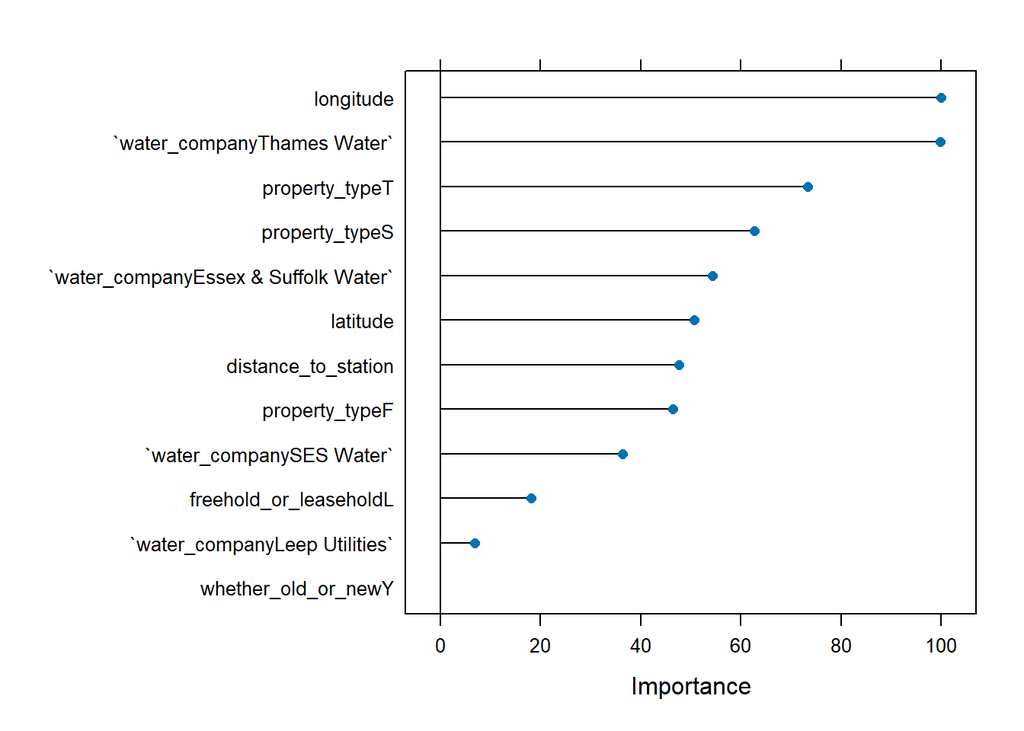

```r
# Evaluate variable importance in the linear regression model
importance <- varImp(model1_lm, scale=TRUE)
plot(importance)
```

## 4.1 Predict the values in testing and out of sample data

Below I use the predict function to test the performance of the model in testing data and summarize the performance of the linear regression model. How can you measure the quality of your predictions?

```r
# Predict prices in the testing dataset
predictions <- predict(model1_lm,test_data)

# Calculate evaluation metrics: RMSE and R-squared
lr_results<-data.frame(  RMSE = RMSE(predictions, test_data$price),
                            Rsquare = R2(predictions, test_data$price))

lr_results
```

```
##       RMSE   Rsquare
## 1 440579.3 0.1776749
```

```r
# Predict prices for the out-of-sample dataset
predictions_oos <- predict(model1_lm,london_house_prices_2019_out_of_sample)
```

# 5 Fit a tree model

Compare the performance of the linear regression model with the tree model; which one performs better? Why do you think that is the case?

```r
# Train a decision tree model
set.seed(123) # Set seed for reproducibility of decision tree training
model2_tree <- train(
  price ~ distance_to_station + water_company + property_type + whether_old_or_new + latitude + longitude,
  data = train_data,
  method = "rpart",
  trControl = control,
  tuneLength = 10 # Explore 10 hyperparameter settings for the tree
)
# Display results of the trained tree model
model2_tree$results
```

```
##            cp     RMSE  Rsquared      MAE   RMSESD RsquaredSD     MAESD
## 1  0.01035976 433546.0 0.3437301 224333.2 24241.22 0.05459941  5232.289
## 2  0.01067649 435545.9 0.3378059 227675.7 23508.48 0.05126783  3311.473
## 3  0.01404523 444473.1 0.3072012 236011.6 33104.55 0.06260052  5136.296
## 4  0.01643920 440024.8 0.3187915 235539.0 34873.73 0.08649907  6120.433
## 5  0.02857529 453340.1 0.2783804 240079.2 40780.95 0.08953237  6978.154
## 6  0.03029526 453340.1 0.2783804 240079.2 40780.95 0.08953237  6978.154
## 7  0.03643516 458310.3 0.2611621 241849.6 44879.89 0.09844137  8490.009
## 8  0.04525601 472418.1 0.2088170 249662.1 38908.44 0.07165916  7165.348
## 9  0.05307855 487393.1 0.1522130 255986.3 47543.25 0.04070308 11617.939
## 10 0.05317292 495882.0 0.1504787 262408.2 47627.21 0.04678605 17660.887
```

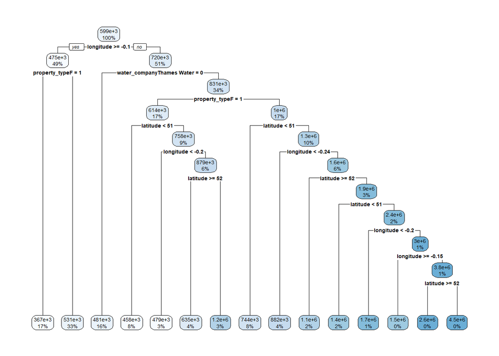

```r
# Visualize the final decision tree
rpart.plot(model2_tree$finalModel)
```

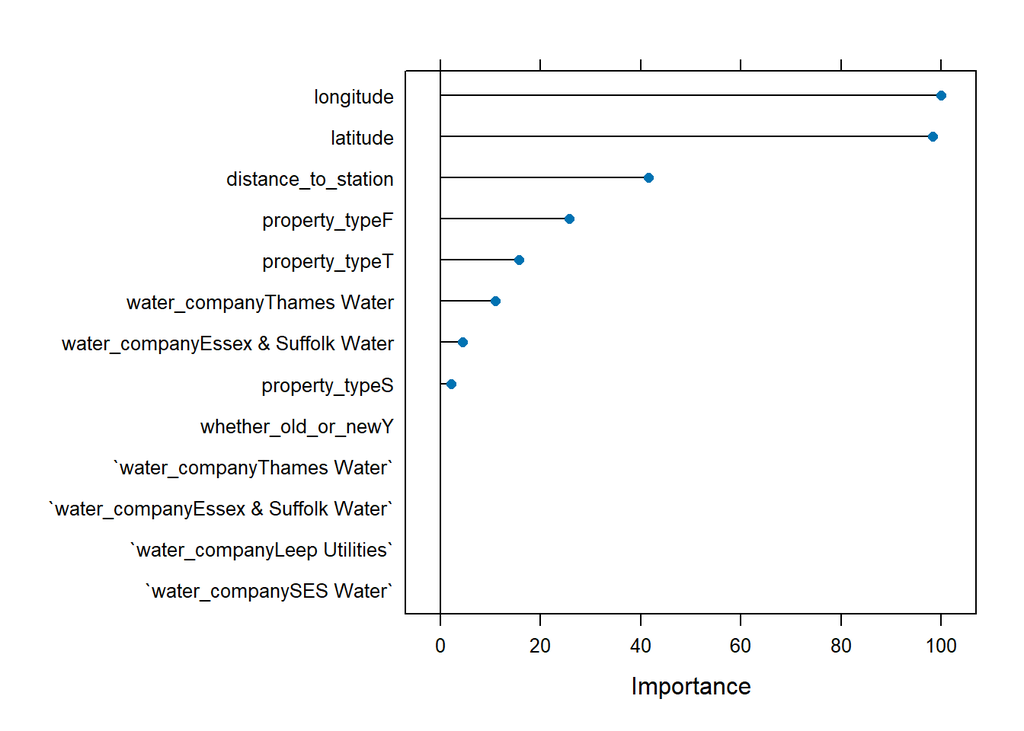

```r
# Evaluate variable importance for the tree model
importance <- varImp(model2_tree, scale = TRUE)
plot(importance)
```

# 6 Other algorithms

Use at least two other algorithms to predict prices. Don’t forget to tune the parameters of these algorithms. And then compare the performances of your algorithms to linear regression and trees.

# 7 Gradient Boosting

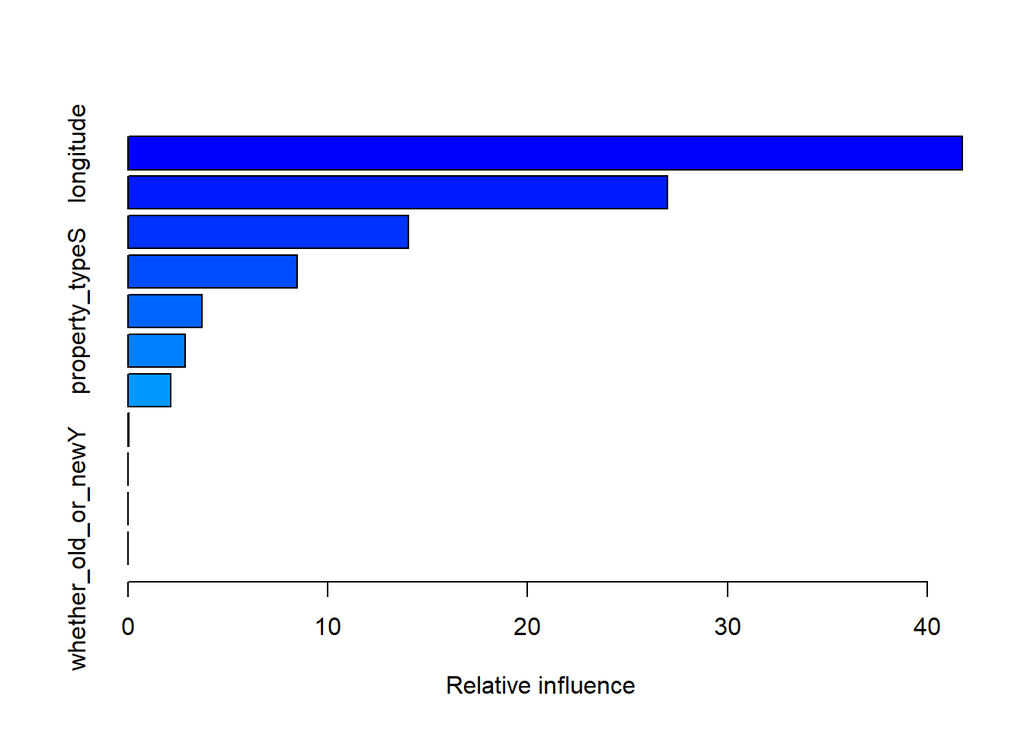

```
##                                                                   var
## longitude                                                   longitude
## latitude                                                     latitude
## property_typeF                                         property_typeF
## water_companyThames Water                   water_companyThames Water
## property_typeS                                         property_typeS
## distance_to_station                               distance_to_station
## property_typeT                                         property_typeT
## water_companySES Water                         water_companySES Water
## water_companyEssex & Suffolk Water water_companyEssex & Suffolk Water
## water_companyLeep Utilities               water_companyLeep Utilities
## whether_old_or_newY                               whether_old_or_newY
##                                        rel.inf
## longitude                          41.75953534
## latitude                           27.00883753
## property_typeF                     14.04478158
## water_companyThames Water           8.47283592
## property_typeS                      3.69589502
## distance_to_station                 2.85599665
## property_typeT                      2.13271937
## water_companySES Water              0.02939858
## water_companyEssex & Suffolk Water  0.00000000
## water_companyLeep Utilities         0.00000000
## whether_old_or_newY                 0.00000000
```

```r
# Train a Gradient Boosting Machine (GBM) model
set.seed(123) # Set seed for reproducibility of GBM training
model3_gbm <- train(
  price ~ distance_to_station + water_company + property_type + whether_old_or_new + latitude + longitude, # Selected features
  data = train_data, # Training data
  method = "gbm", # Specify GBM as the method
  trControl = control, # Use defined cross-validation settings
  verbose = FALSE # Suppress detailed training output
)
# Summarize the results of the GBM model
library(gbm)
summary(model3_gbm)
```

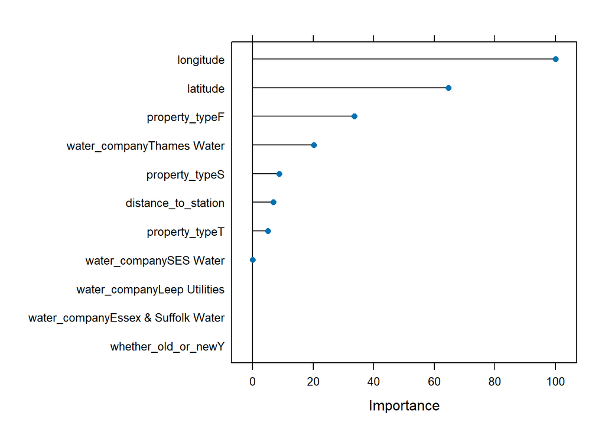

```r
# Evaluate the importance of variables in the GBM model
importance <- varImp(model3_gbm, scale = TRUE) # Scaled variable importance
plot(importance) # Visualize variable importance
```